# Exercise 10: Rmarkdown & Parameters

Chris Mainey

14/01/2020

## R Markdown Exercise

This exercise is used to develop a sample report using the `LOS_model` dataset from the `NHSRdatasets` package. More information about this package is avaialble at: [here](https://cran.r-project.org/web/packages/NHSRdatasets/index.html).

## Full dataset statistics

Here is a summary of the LOS using `dplyr`, collapsing the results into a single piece of code, with warnings surpressed, and using `knitr::kable` on the table to format it nicely.

```r
library(dplyr)
LOS_model %>%
  summarise("Mean LOS" = mean(LOS),
            "Median LOS" = median(LOS))  %>%
  knitr::kable(caption = "LOS_model summary data for all organisations")
```

LOS_model summary data for all organisations

| Mean LOS | Median LOS |
| --- | --- |
| 4.936667 | 4 |

Now we will create a histogram of the LOS stay:

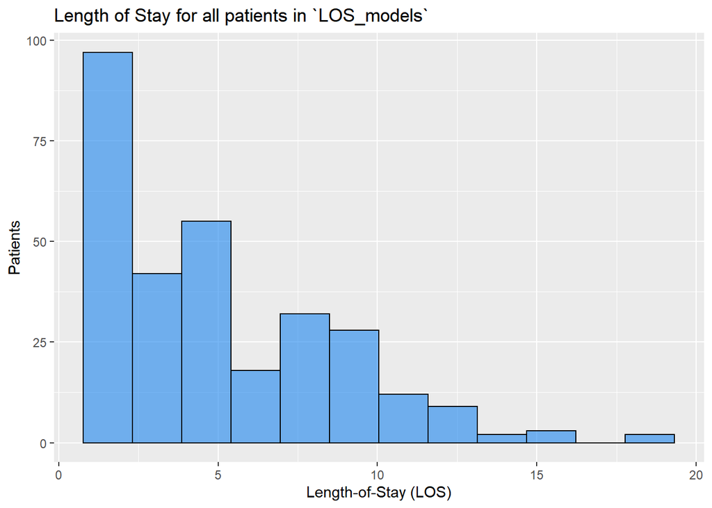

```r
library(ggplot2)
ggplot(LOS_model, aes(x=LOS)) +
  geom_histogram(fill="dodgerblue2", alpha=0.6, col=1, bins=12) +
  labs(title = "Length of Stay for all patients in `LOS_models`") +
  scale_x_continuous(name="Length-of-Stay (LOS)")+
  scale_y_continuous(name="Patients")
```

## Report For Trust1

It is possible to change the in-line text using parameters. The title of this section of the report takes the value of the ‘Trust’ parameter.

We will use the same code from above, but using `filter` to return the data for the organisation named in the parameter ‘Trust’.

```r
LOS_model %>%
  filter(Organisation == params$Trust) %>%
  summarise("Mean LOS" = mean(LOS),
            "Median LOS" = median(LOS))  %>%
  knitr::kable(caption = paste("LOS_model summary data for", params$Trust))
```

LOS_model summary data for Trust1

| Mean LOS | Median LOS |
| --- | --- |
| 5.066667 | 5 |

Here I’ve used the subset function rather than filter, as its another way to do the same thing and is marginally quicker than filter.

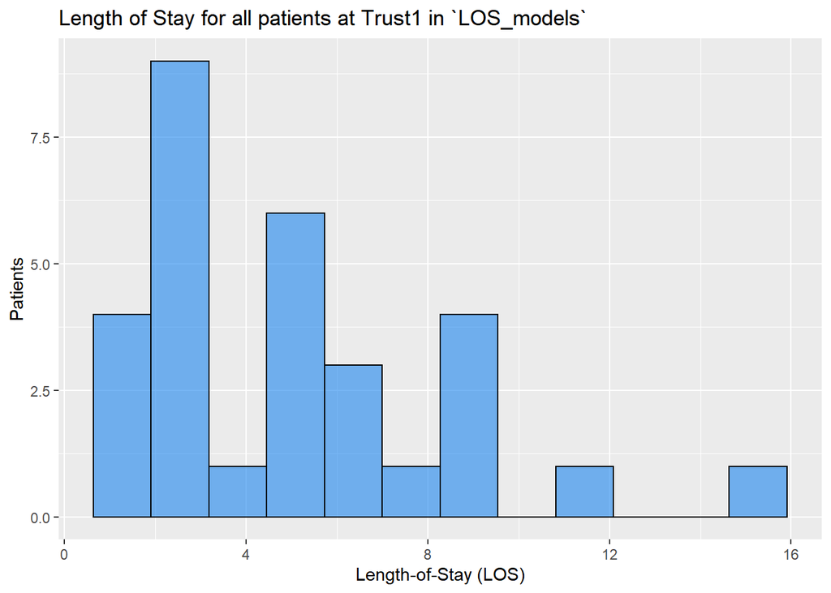

```r
ggplot(subset(LOS_model, Organisation==params$Trust), aes(x=LOS)) +
  geom_histogram(fill="dodgerblue2", alpha=0.6, col=1, bins=12) +
  labs(title = paste("Length of Stay for all patients at",  params$Trust, "in `LOS_models`")) +
  scale_x_continuous(name="Length-of-Stay (LOS)")+
  scale_y_continuous(name="Patients")
```

The report text can be changed based on the performance of each trust. The sentence below will tell us if this trust has an average length of stay which is below or above average.

Trust1 has a length of stay which is longer than average..